# High-volume Data Wrangling, Analysis, and Visuals

Monica Kullar

### This is a large datasheet of **220,150 rows and 21 columns** originally downloaded as a text file with lots of messiness to unpack, document, and organize!

Here I provide code for (1) reading-in and cleaning data systematically to process, (2) subsetting and organizing data by blocks based on differing timescales, (3) confirming data integrity, (4) troubleshooting possible data issues, (5) creating wide versions of the data and probing missingness to consider impact on analysis, and (6) providing a analysis and data visualization sample (exploring data, visual trends by groups, and analyzing group differences on a calculated metric from the data).

```r
# all packages used across all script chunks
library(plyr)
library(dplyr)
library(tidyr)
library(VIM)
library(mice)
library(zoo)
library(ggplot2)
library(ggpubr)
library(wesanderson)
library(svglite)
library(data.table)
library(rstatix)
```

## (1) Reading in the data

I read in, correct variable IDs to be intuitive, debug various recordkeeping issues, and recode certain output formats to begin processing data.

```r
### Read in datasheet containing null response timepoints .txt file
esmnull <- read.delim(file = "~/ownCloud/PhD/Projects/Data/ESM/ESM2019_data_2020-06-01_16_52_01_with_null_values_comma_header_95_15_16_17.txt", sep = ",", na.strings=c(""), header = T, stringsAsFactors = FALSE, colClasses = "character")
sapply(esmnull, class) # check the class of variables to confirm what is appropriate and what needs transformations - should transform time from a character to a number
```

```
##            study             user          moniker         qblockid
##      "character"      "character"      "character"      "character"
##           qblock                q              ans            speed
##      "character"      "character"      "character"      "character"
##          heading         altitude         latitude        longitude
##      "character"      "character"      "character"      "character"
##    avgTouchForce orientationAlpha  orientationBeta orientationGamma
##      "character"      "character"      "character"      "character"
##        timepoint       testingday   clientDateTime       serverTime
##      "character"      "character"      "character"      "character"
##                X
##      "character"
```

```r
### Eliminate testing day of time 0 from improper start input of two participants
esmnull <- esmnull %>%
  filter(testingday != '0')  # eliminate testing days read in as day0 from improper start input of two participants
### Create time variable instead of multiple time ID columns for improved data visuals to come in handy later.
esmnull <- esmnull %>% unite('time', testingday:timepoint, sep = ".", remove = FALSE)
### Shorten datasheet to variables of interest by column name
testvar <- c("moniker", "qblock", "q", "ans", "timepoint", "testingday", "time")
esmnull <- esmnull[testvar]
### Remove test ID used in piloting (999) and excluded dropouts. Because there are so many multiple rows per ID variable, dplyr's filter sometimes incorrectly only removes the first instances, thus base R provides a quicker resolution of all exclusions.
esmnull <- esmnull[!(esmnull$moniker=="999"),]
esmnull <- esmnull[!(esmnull$moniker=="2"),]
esmnull <- esmnull[!(esmnull$moniker=="19"),]
esmnull <- esmnull[!(esmnull$moniker=="35"),]
esmnull <- esmnull[!(esmnull$moniker=="85"),]
esmnull <- esmnull[!(esmnull$moniker=="103"),]

### Eliminate blank 'q' for instruction screens (this is not actual missing data, and I want to accurately assess missingness later)
blankq <- !is.na(esmnull$q) #confirm first if these blanks register as FALSE
sum(blankq, na.rm = TRUE) #total number of TRUEs, for quality control to confirm we removed correct NAs
```

```
## [1] 204484
```

```r
length(blankq[blankq==FALSE]) #another way to count, for FALSEs
```

```
## [1] 6886
```

```r
#eliminate NAs from 'q' column specifically for blank screens that were displayed between questions
esmnull <- esmnull %>% filter(!is.na(q))
### There are multiple observations where Likert scales have been read in as "1-text" and "7-text" for anchor points, rename these answers, and any yes/no to become binary
esmnull$ans[startsWith(esmnull$ans, "1")] <-  "1"
esmnull$ans[startsWith(esmnull$ans, "7")] <-  "7"
esmnull$ans[startsWith(esmnull$ans, "no")] <-  "0"
esmnull$ans[startsWith(esmnull$ans, "yes")] <-  "1"

### There is a key such that within each of the 2 question blocks, qblock and q columns represent certain variables of interest. Let's rename these to be more intuitive in further processing, visualization, and analysis. Long version by qblock/q and intuitive new name.
intuitvarnames1 <- data.frame ('qblock'=c(rep(1,18), rep(2,25)), 'q'=c(1:18, 1:25), 'newq'=c('CurrentTask', 'MWoccur', 'MWvalence', 'MWsubject', 'MWtemporal',  'MWimmers', 'MWcontrol', 'MWspecif', 'Enthusiastic', 'Happy_e', 'Pleased', 'Relaxed', 'Nervous', 'Sad', 'Angry', 'Irritated', 'Stressed', 'EmotionChronometry', 'SleepTime',  'WakeTime',  'SleepHours', 'SleepQuality', 'Happy_m', 'Lively', 'Content', 'Satisfied', 'Depressed', 'Bored', 'Anxious', 'Irritable', 'Tense', 'MoodStuck', 'MoodRegAttempt', 'CogAvoid', 'BehavAvoid',  'CogRelax', 'BehavRelax', 'CogDistract', 'BehavDistract', 'CogReapp', 'SupportSeek', 'ProbSolve', 'Accept'))
intuitvarnames2 <- data.frame ('qblock'=c(rep(2,19)), 'q'=c('5t', '6t', '7t', '8t', '9t', '10t', '11t', '12t', '13t', '16e', '17e', '18e', '19e', '20e', '21e', '22e', '23e' ,'24e', '25e'), 'newq'=c('Happy_mChronometry', 'LivelyChronometry', 'ContentChronometry', 'SatisfiedChronometry', 'DepressedChronometry', 'BoredChronometry', 'AnxiousChronometry', 'IrritableChronometry', 'TenseChronometry', 'CogAvoidEffic', 'BehavAvoidEffic', 'CogRelaxEffic', 'BehavRelaxEffic', 'CogDistractEffic', 'BehavDistractEffic', 'CogReappEffic', 'SupportSeekEffic', 'ProbSolveEffic', 'AcceptEffic'))  #this is even more name variables that aren't denoted by a purely numerical q value, like the other dataframe above

intuitvarnames <- rbind(intuitvarnames1, intuitvarnames2) #bind the rows for a master "intuitive variable name key" of mind wandering, emotions, moods, mood chronnometry and mood regulation efficacy.
esmnull <- merge(esmnull, intuitvarnames, by = c("qblock", "q"), all.x = TRUE)
esmnull <- dplyr::rename(esmnull, oldq = q, q = newq) #let's rename our old q so we don't continue to use that, and let's rename our new q intuitive variable names so we may shorten our dataset one last time to the most relevant variables as we move on.

esmnull <- esmnull[testvar] #get rid of blank variable columns used to rename variables to be intuitive
```

## (2) Subsetting Data

Here I split the data into subsets for analysis aims to better process the large dataset, since each of the two question blocks technically operate on different timescales and should be treated as two datasets later on (block 1 has 70 timepoints, but block 2 has 14 timepoints taken separately).

```r
#### Confirm the class for variables as we begin to further set up for analysis.
#Change data types based on column
factorvar <- c("q", "moniker") #these ought to be factors
esmnull[factorvar] <- lapply(esmnull[factorvar], as.factor)
numericvar <- c("qblock", "timepoint", "testingday", "time") #these ought to be numeric
esmnull[numericvar] <- lapply(esmnull[numericvar], as.numeric)
#recheck final mode and class to confirm changes set
sapply(esmnull, mode)
```

```
##     moniker      qblock           q         ans   timepoint  testingday
##   "numeric"   "numeric"   "numeric" "character"   "numeric"   "numeric"
##        time
##   "numeric"
```

```r
sapply(esmnull, class)
```

```
##     moniker      qblock           q         ans   timepoint  testingday
##    "factor"   "numeric"    "factor" "character"   "numeric"   "numeric"
##        time
##   "numeric"
```

```r
### Subset data relevant to Emotion analysis aims
emoterm <- c("Enthusiastic", "Happy_e", "Pleased", "Relaxed", "Nervous", "Sad", "Angry", "Irritated", "Stressed", "EmotionChronometry")
emoonlynull <- subset(esmnull, subset = q %in% emoterm) #shorten emotion data
emoonlynull$ans <- as.numeric(emoonlynull$ans) #change ans to data type per subset
sapply(emoonlynull, class) #created a subset of data of all emotion terms
```

```
##    moniker     qblock          q        ans  timepoint testingday       time
##   "factor"  "numeric"   "factor"  "numeric"  "numeric"  "numeric"  "numeric"
```

```r
### Subset data relevant to Mind Wandering analysis aims
mwterm <- c("MWoccur", "MWvalence", "MWsubject", "MWtemporal", "MWimmers", "MWcontrol", "MWspecif")
mwonlynull <- subset(esmnull, subset = q %in% mwterm)
mwonlynull$ans <- as.numeric(mwonlynull$ans) #created a subset of data with all mind-wandering

### The following removes the existence of NA rows for faulty missing data  - that is, the mind wandering follow-up questions are not displayed if occurence was no (coded as 0) - so the following NA values are not true missing data, simply uncollected.
mwonlynull <- mwonlynull %>%
    group_by(moniker,time) %>%
    filter(row_number() <= min(which(is.na(ans) == TRUE & lag(ans) == 0))-1) #Find the first row with "0,na" pattern in each group, filter out rows after it by going to the minimum row "0,na" that meets this condition and backtracking one more so only the first row (MWoccur =0) stays
  #may display error but all is fine - double checked with mathematical truth of observations removed versus present.
class(mwonlynull) # has multiple classes, which will cause issues in merging via rbind
```

```
## [1] "grouped_df" "tbl_df"     "tbl"        "data.frame"
```

```r
mwonlynull <- as.data.frame(mwonlynull) #corrected to now only read in as data.frame
class(mwonlynull) #recheck, confirmed correct!
```

```
## [1] "data.frame"
```

```r
### Subset data for block 1 (all timepoints on same testing scale (time 1 to 5))
block1onlynull <- rbind(mwonlynull, emoonlynull) #use rbind, not merge, because all variables are the exact same, so binds vertically.
class(block1onlynull)
```

```
## [1] "data.frame"
```

```r
### Subset data for block 2 (Mood analysis) (all timepoints on same testing scale (time 6))
allblock2 <- c("2")
block2onlynull <- subset(esmnull, subset = qblock %in% allblock2)
block2onlynull$ans <- as.numeric(block2onlynull$ans) #created a subset for data of all mood terms
class(block2onlynull)
```

```
## [1] "data.frame"
```

# (3) Confirm Data Integrity

Before beginning to analyze data, I really want to make sure this huge set of hundreds of thousands observations isn’t missing anything unexpectedly, whether that be from a glitch, naming issue, or download error. It’s a lot of rows so here I code to check a single random participant to confirm scripting works, then adjust code to work to check the entire sample.

```r
### Confirm the dataset is appropriate and has read in the right number of expected observations (variables) per person per time.
  checkP <- c("17") #First look at a single random participant to confirm responses look okay and no duplicates.
  checkP1 <- subset(esmnull, subset = moniker %in% checkP) #shorten emotion data to this participant
  # Check to see thenumber of observations (rows, aka variables) a single participant may have per timepoint (to confirm data matches expectations)
  vischeck <- ddply(checkP1, .(time), summarize, num.complete = length(time))
  vischeck
```

```
##    time num.complete
## 1   1.1           18
## 2   1.2           18
## 3   1.3           18
## 4   1.4           18
## 5   1.5           18
## 6   1.6           44
## 7   2.1           18
## 8   2.2           18
## 9   2.3           18
## 10  2.4           18
## 11  2.5           18
## 12  2.6           44
## 13  3.1           18
## 14  3.2           18
```

[output cut: 70 more lines]

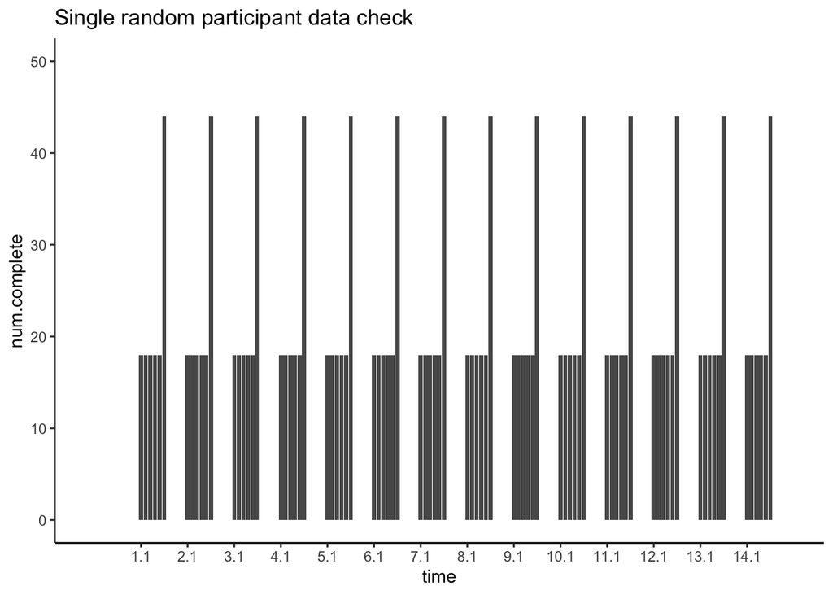

```r
  # We can plot this for the participant as well, to instead see visually that the pattern is correct across time.
  ggplot(vischeck, aes(x=time, y=num.complete)) +
    geom_bar(stat="identity") +
    scale_x_continuous(breaks=c(1.1:14.6), labels=c(1.1:14.6),limits=c(0,15)) +
    scale_y_continuous(limits=c(0,50)) + theme_classic() + ggtitle("Single random participant data check")
```

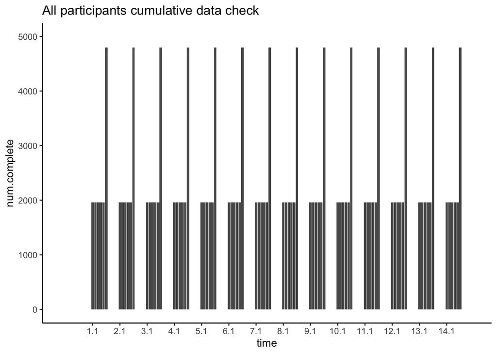

```r
# We want to scale to all participants, so let's check all now.
checkall <- esmnull
#create a sheet with participant_time to assess counts across all 100+ participants
    checkall$ptime <- paste(checkall$moniker,checkall$time, sep = "_") # blend participant and time to create a unique ID for every observation/person/time combination
vischeckall <- ddply(checkall, .(ptime), summarize, num.complete = length(ptime)) #here we can see specific number per person per time, if we need to assess when something was specifically missing.
#let's summarize even more, this will capture total observations per timepoint, which we can divide by number of participants.
vischeckall2 <- ddply(checkall, .(time), summarize, num.complete = length(time))

### Visually confirm the pattern of total completion matches appropriately - if anything is wonky, we can see here which timepoint may have less than expected data and then move forward to finding which participant that belongs to.
  ggplot(vischeckall2, aes(x=time, y=num.complete)) +
    geom_bar(stat="identity") +
    scale_x_continuous(breaks=c(1.1:14.6), labels=c(1.1:14.6),limits=c(0,15)) +
    scale_y_continuous(limits=c(0,5000)) + theme_classic() + ggtitle("All participants cumulative data check")
```

```r
#all is perfect! This means all data is here, and we are ready to move forward to further refining the data formats.
```

# (4) Troubleshooting Example

In a past version of the data, observation counts were not correct. This shows an example of troubleshooting until I am able to discover where things were missing, and reran the above data integrity confirmation until all was correct.

```r
### OldVersion "checkall" has 204,376 observations
# 1,876 observations per participant. N=109. 1,876*109 = 204,484
109*1876 #number of participants (109) * number of observations (1876)
```

```
## [1] 204484
```

```r
# We should have 204,484. If OldVersion has 204,376
204484-204376 #there are 108 missing observations
```

```
## [1] 108
```

```r
#there are 18 variables per block 1 timepoint
 108/18 #Thus, 6 block1 timepoints be missing somewhere...check it out.
```

```
## [1] 6
```

```r
missingtp <- checkall[,c(1, 5:8)] #shorten data to relevant columns
missingtp <- unique(missingtp) # shorten down to focus on finding out which participants are missing timepoints.

vistp <- ddply(missingtp, .(time), summarize, num.complete = length(time)) #visualize which timepoints have an imbalanced number complete to locate with timepoints are missing.
#missing one 5.3, one 5.4, two 6.3, and two 6.4. found the 6 missing timepoints!!
findmissing <- checkall[(checkall$time=="6.4"),] #check here per ID
findmissing <- findmissing[,c(1, 7)]
findmissing <- unique(findmissing)
findmissing$moniker <- as.numeric(findmissing$moniker) # make sure moniker is numeric rather than a factor for sorting ease here.
    sorted_moniker <- paste(sort(as.integer(levels(findmissing$moniker)))) #order by ascending value.

# With this, we see that missing timepoints discovered to belong to...
#ID=15 missing 6.3, 6.4
#ID=16 missing 6.3, 6.4
#ID=17 missing 5.3, 5.4

###
# SOLVED! This is an error in how data was read in, and may have been a server issue. Correct the .txt file if needed for null rows to accurately reflect full missingness.
```

# (5) Wide Versions of Data and Missingness

- I want to create a wide format version using ‘tidyr’ in addition to the original long version for my 2 data blocks in order to assess missingness through ‘mice’ and also plot easily where applicable. The long data version is still useful for other analyses and plots later on.

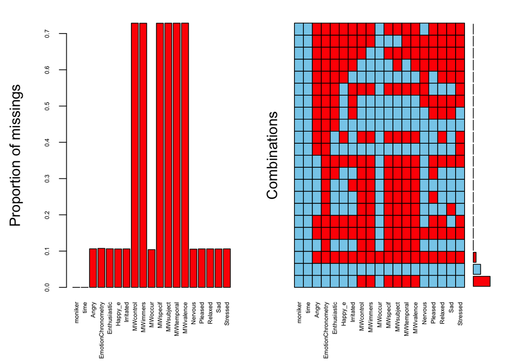

```r
### Read in the data and convert to wide format for certain analyses and visualizations
#BLOCK 1
widerblock1 <- rbind(mwonlynull, emoonlynull)
c <- c("moniker", "q", "ans", "time")
widerblock1 <- widerblock1[c]
block1onlynullWIDE <- spread(widerblock1, q, ans)

#BLOCK 2
widerblock2 <- block2onlynull
c <- c("moniker", "q", "ans", "time")
widerblock2 <- widerblock2[c]
block2onlynullWIDE <- spread(widerblock2, q, ans)

### Assessing missingness
  #block1
  miss1 <- block1onlynullWIDE
        #supershort for GIMME
        gimmemissvar <- c("moniker", "time", "Happy_e", "Pleased", "Enthusiastic", "Relaxed", "Angry", "Irritated", "Stressed", "Sad", "Nervous", "MWoccur", "EmotionChronometry")
        gimmemiss <- miss1[gimmemissvar]
      #method 1: VIM
      aggr(miss1, cex.axis = .5) #one way to visualize missingness with "VIM"
```

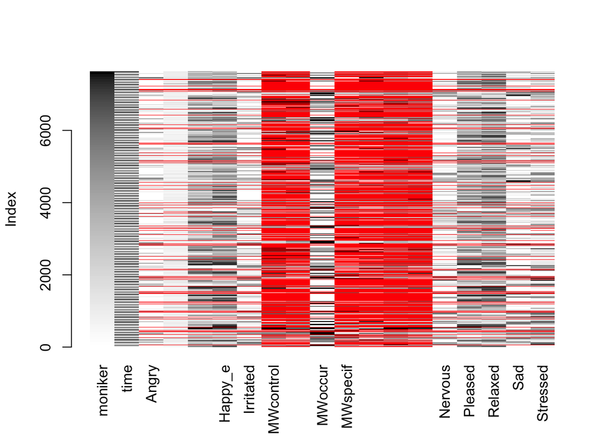

```
##
## Click in a column to sort by the corresponding variable.
## To regain use of the VIM GUI and the R console, click outside the plot region.
```

```r
      matrixplot(miss1) #a matrix plot for missingness
```

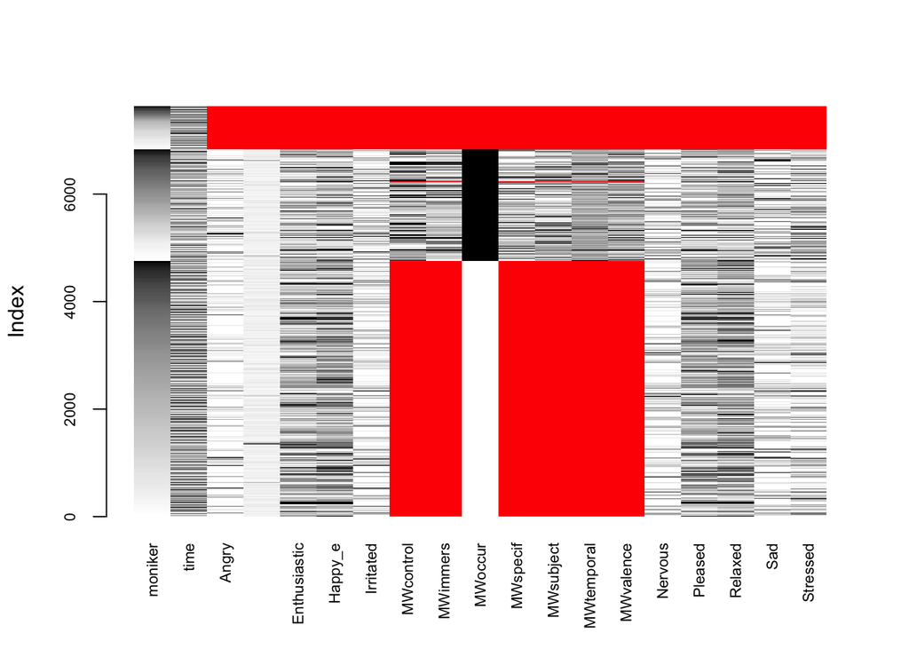

```
##
## Click in a column to sort by the corresponding variable.
## To regain use of the VIM GUI and the R console, click outside the plot region.
```

```r
      matrixplot(miss1, sortby = c("MWoccur"), cex.axis = .7) #sorting by the original branching MW question where the 'false' missing values may appear, confirming that most missing data is related to branching logic for those questions.
```

```r
      #method 2: mice
      md.pattern(gimmemiss, plot = FALSE, rotate.names = TRUE) #check what proportion is missing
```

```
##      moniker time MWoccur Nervous Happy_e Sad Pleased Relaxed Irritated
## 6810       1    1       1       1       1   1       1       1         1
## 4          1    1       1       1       1   1       1       1         1
## 1          1    1       1       1       1   1       1       1         1
## 1          1    1       1       1       1   1       1       1         1
## 1          1    1       1       1       1   1       1       1         0
## 1          1    1       1       1       1   1       0       1         1
## 1          1    1       1       1       1   1       0       1         1
## 1          1    1       1       1       1   0       1       1         1
## 1          1    1       1       1       1   0       0       0         0
## 1          1    1       1       1       0   1       1       0         1
## 2          1    1       1       1       0   1       0       0         0
## 1          1    1       1       1       0   0       0       0         0
## 1          1    1       1       1       0   0       0       0         0
## 1          1    1       1       0       1   1       1       1         0
```

[output cut: 25 more lines]

```r
      pMiss <- function(x){sum(is.na(x))/length(x)*100} #calculate to view percent of missingness per variable
      apply(miss1,2,pMiss) #roughly 10% missing across non-MW variables, great!
```

```
##            moniker               time              Angry EmotionChronometry
##            0.00000            0.00000           10.62910           10.74705
##       Enthusiastic            Happy_e          Irritated          MWcontrol
##           10.62910           10.57667           10.60288           72.85714
##           MWimmers            MWoccur           MWspecif          MWsubject
##           72.84404           10.40629           72.84404           72.85714
##         MWtemporal          MWvalence            Nervous            Pleased
##           72.85714           72.87025           10.53735           10.60288
##            Relaxed                Sad           Stressed
##           10.60288           10.57667           10.61599
```

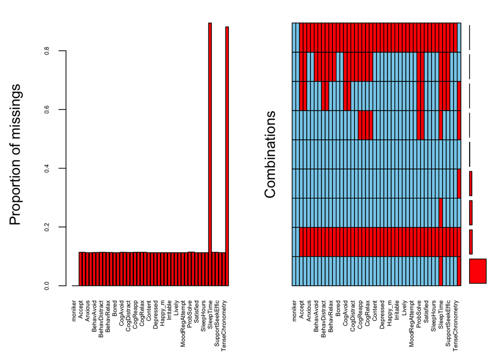

```r
  #block2
  miss2 <- block2onlynullWIDE
  aggr(miss2, cex.axis = .5)
```

```r
  md.pattern(miss2, plot = FALSE, rotate.names = TRUE)
```

```
##      moniker time Anxious AnxiousChronometry Bored BoredChronometry Content
## 16         1    1       1                  1     1                1       1
## 163        1    1       1                  1     1                1       1
## 145        1    1       1                  1     1                1       1
## 1027       1    1       1                  1     1                1       1
## 1          1    1       1                  1     1                1       1
## 1          1    1       1                  1     1                1       1
## 1          1    1       1                  1     1                1       1
## 1          1    1       0                  0     0                0       0
## 171        1    1       0                  0     0                0       0
##            0    0     172                172   172              172     172
##      ContentChronometry Depressed DepressedChronometry Happy_m
## 16                    1         1                    1       1
## 163                   1         1                    1       1
## 145                   1         1                    1       1
```

[output cut: 84 more lines]

```r
  apply(miss2,2,pMiss) #roughly 11% missing across variables, great! SleepTime and WakeTime are missing for almost all participants (90%) due to a collection issue and won't be able to be used in analysis.
```

```
##              moniker                 time               Accept
##              0.00000              0.00000             11.40236
##          AcceptEffic              Anxious   AnxiousChronometry
##             11.40236             11.27130             11.27130
##           BehavAvoid      BehavAvoidEffic        BehavDistract
##             11.33683             11.33683             11.40236
##   BehavDistractEffic           BehavRelax      BehavRelaxEffic
##             11.40236             11.33683             11.33683
##                Bored     BoredChronometry             CogAvoid
##             11.27130             11.27130             11.40236
##        CogAvoidEffic          CogDistract     CogDistractEffic
##             11.40236             11.33683             11.33683
##             CogReapp        CogReappEffic             CogRelax
##             11.40236             11.40236             11.40236
##        CogRelaxEffic              Content   ContentChronometry
##             11.40236             11.27130             11.27130
##            Depressed DepressedChronometry              Happy_m
##             11.27130             11.27130             11.27130
##   Happy_mChronometry            Irritable IrritableChronometry
##             11.27130             11.27130             11.27130
##               Lively    LivelyChronometry       MoodRegAttempt
##             11.27130             11.27130             11.27130
##            MoodStuck            ProbSolve       ProbSolveEffic
##             11.27130             11.46789             11.46789
##            Satisfied SatisfiedChronometry           SleepHours
##             11.27130             11.27130             11.27130
##         SleepQuality            SleepTime          SupportSeek
##             11.27130             89.44954             11.40236
##     SupportSeekEffic                Tense     TenseChronometry
##             11.40236             11.27130             11.27130
##             WakeTime
##             88.13893
```

```r
### Check for missingess patterns across the diagnostic groups - load these groups in now.
groupcomplete <- read.csv(file = "~/ownCloud/PhD/Projects/Data/ESM/ESM group percent complete.csv", sep=',', na.strings=c(""), header = T, stringsAsFactors = FALSE, colClasses = "character")
sapply(groupcomplete, class) #change the variables to the correct class
```

```
##           ID_ESM Percent.Complete            Group
##      "character"      "character"      "character"
```

```r
groupcomplete$ID_ESM <- as.numeric(groupcomplete$ID_ESM)
groupcomplete <- groupcomplete %>%
  dplyr::rename(moniker = ID_ESM) #rename the "ID_ESM" to "moniker" so we can blend this with our dataset for group status.
groupcomplete$Percent.Complete <- as.numeric(groupcomplete$Percent.Complete)
groupcomplete$Group <- as.factor(groupcomplete$Group)
levels(groupcomplete$Group) #check levels
```

```
## [1] "BPD"      "Healthy"  "MDD"      "Remitted"
```

```r
levels(groupcomplete$Group) <- c("Bipolar", "Healthy", "Depressed", "Remitted") #rename levels for Group as I prefer to plot, based on their order from above
groupcomplete$Group <- factor(groupcomplete$Group, levels = c("Depressed", "Remitted", "Bipolar", "Healthy")) #reorder levels as I prefer for plotting

groupcomplete %>% # Gather summary statistics of the percent complete across participants
group_by(Group) %>%
  summarise(
    mean = mean(Percent.Complete, na.rm = TRUE),
    sd = sd(Percent.Complete, na.rm = TRUE)
  )
```

```
## # A tibble: 4 x 3
##   Group      mean     sd
##   <fct>     <dbl>  <dbl>
## 1 Depressed 0.873 0.131
## 2 Remitted  0.895 0.109
## 3 Bipolar   0.885 0.116
## 4 Healthy   0.932 0.0685
```

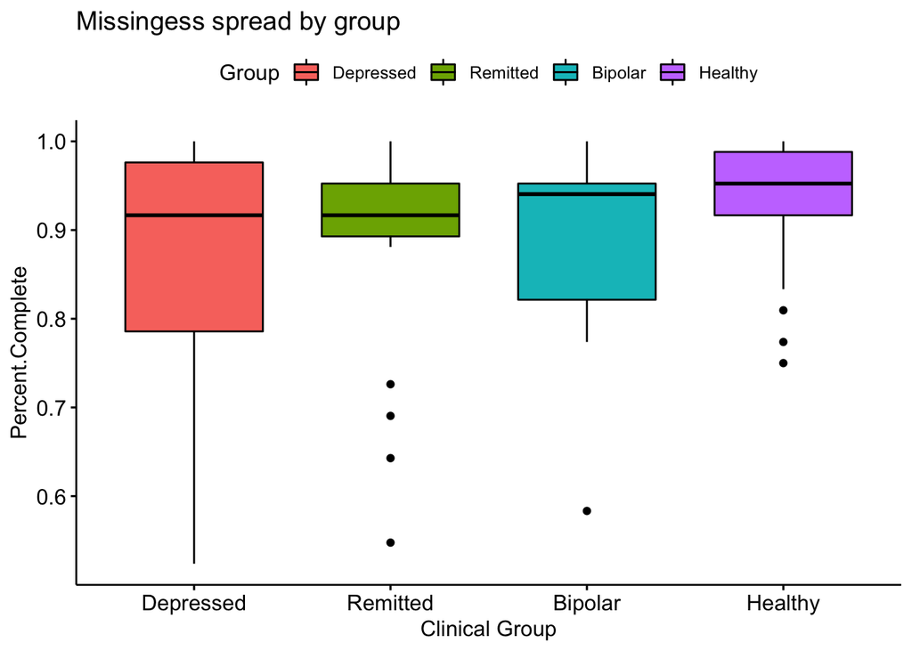

```r
### Visualizing missingness by groups
# Boxplot by group
ggboxplot(groupcomplete, x = "Group", y = "Percent.Complete",
          fill = "Group",
          ylab = "Percent.Complete", xlab = "Clinical Group") + ggtitle("Missingess spread by group")
```

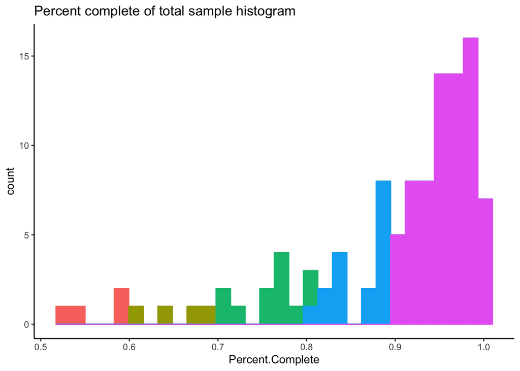

```r
# Create new column for limits on missingness
groupcomplete$Colour=""
# Set new column values to graphing specific colors per general range I have selected
groupcomplete$Colour[groupcomplete$Percent.Complete>=.5]="5"
groupcomplete$Colour[groupcomplete$Percent.Complete>=.6]="6"
groupcomplete$Colour[groupcomplete$Percent.Complete>=.7]="7"
groupcomplete$Colour[groupcomplete$Percent.Complete>=.8]="8"
groupcomplete$Colour[groupcomplete$Percent.Complete>=.9]="9"
# Histogram
ggplot(groupcomplete, aes(x=Percent.Complete, color = Colour, fill = Colour)) + geom_histogram() + theme_classic() + theme(legend.position = "none") + ggtitle("Percent complete of total sample histogram") #shows data is skewed, so does not meet assumption needed for ANOVA. Use Kruskal-Wallis test instead.
```

```r
  kruskal.test(Percent.Complete ~ Group, data = groupcomplete) #Compute Kruskal-Wallis rank sum test
```

```
##
##  Kruskal-Wallis rank sum test
##
## data:  Percent.Complete by Group
## Kruskal-Wallis chi-squared = 3.7238, df = 3, p-value = 0.2929
```

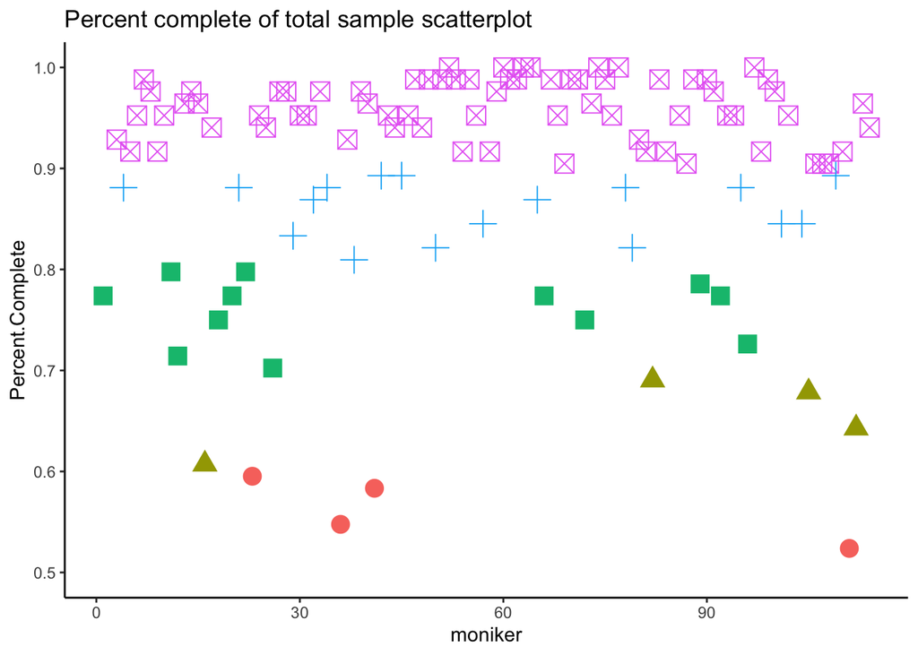

```r
# Scatterplot
ggplot(groupcomplete, aes(x=moniker, y=Percent.Complete, colour = factor(Colour), shape = Colour)) +
geom_point(aes(size=1)) + theme_classic() +
  ylim(0.5,1) + theme(legend.position = "none") + ggtitle("Percent complete of total sample scatterplot")
```

```r
### Briefly check missingness of Mood info from Block 2, as the original exclusions based on "number complete" may possibly meet inclusion critera if related to completion rate for this separate timescale.
check <- aggregate(Anxious ~ moniker, data=block2onlynullWIDE, function(x) {sum(is.na(x))}, na.action = NULL) #use an exemplar mood
table(check$Anxious) #the number of individuals missing data to review.
```

```
##
##  0  1  2  3  4  5  6  7  8
## 43 23 17  8  5 10  1  1  1
```

```r
#participant 36 missing 8 (will still keep since only excluding those missing 60%+ here) - all is good to continue!
```